# Remuneração Servidores Públicos Ativos do EMG

Francisco Alves

Este arquivo é um documento [rmarkdown](https://rmarkdown.rstudio.com/). O rmarkdown é um documento dinâmico que permite a combinação de texto, escrito em markdown, com trechos de código em R.

No trecho abaixo, vamos importar a base de dados com a remuneração dos servidores ativos do Poder Executivo do Estado de Minas Gerais (EMG).

```r
#======================================================================
# necessário utilizar arquivo completo "data-raw/servidoresMG_1219.csv" de
# http://200.198.22.105/fgs-adm/remuneracao/downloadRemuneracao.php?mes=1219
# para manipulação com filter() e head() ser necessária
#======================================================================

df <- read_csv2("data-raw/servidoresMG_1219_top10.csv",
  col_types = "ccccccccnnncnnnnnnnnnnnnnnnnnnnnnnn",
)
```

O primeiro princípio para compreensão de dados é

> **Shewhart’s Rule One for the Presentation of Data:**

> *Data should always be presented in such a way that preserves the evidence in the data for all the predictions that might be made from these data.*

Segundo @wheeler2000, esse princípio sugere que

1. A table of values should accompany most graphs;
2. A graph should accompany any table.

O [tufte handout](https://rstudio.github.io/tufte/) é um estilo de documento utilizado por [Edward Tufte](https://en.wikipedia.org/wiki/Edward_Tufte) em seus livros que faz uso intensivo de anotações laterais para inserção de conteúdo.

Esse documento é ideal para seguirmos o primeiro princípio para compreensão de dados. Um caso concreto ajuda a clarificar o método.

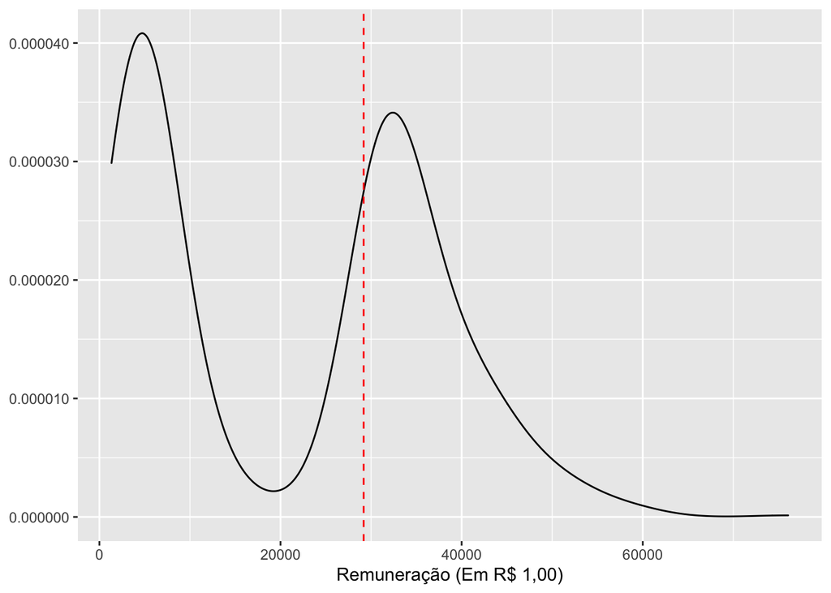

Distribuição da remuneração dos servidores da AGE

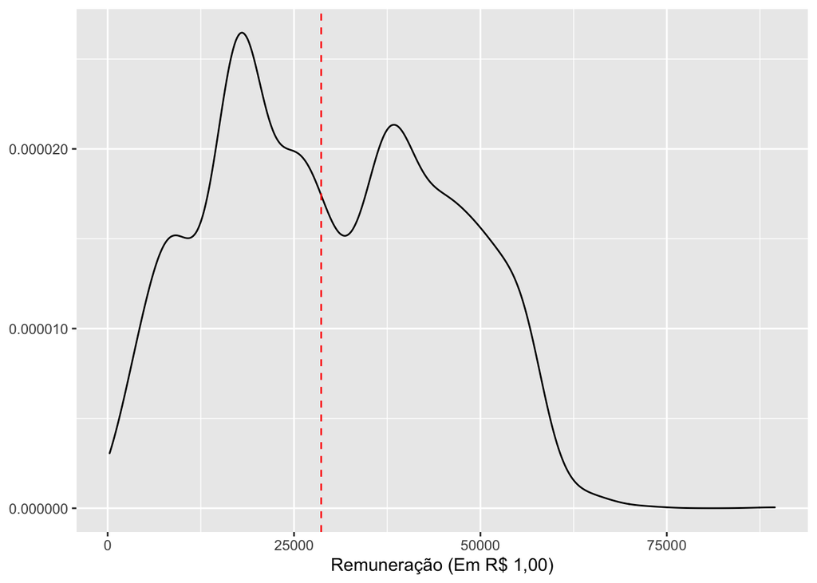

Distribuição da remuneração dos servidores da SEF

| Órgão ou Entidade | Mediana Remuneração | Qtd. Pagamentos |
| --- | --- | --- |
| ADVOCACIA GERAL DO ESTADO | 29242.64 | 794 |
| SECRETARIA DA FAZENDA | 28705.02 | 2918 |
| CONTROLADORIA GERAL DO ESTADO | 19272.79 | 191 |
| FUNDACAO JOAO PINHEIRO | 13150.94 | 223 |
| FEAM FUNDACAO DO MEIO AMBIENTE | 12978.59 | 104 |
| IGAM INST DE GESTAO DAS AGUAS | 12780.12 | 150 |
| SECRETARIA DO MEIO AMBIENTE | 11557.99 | 830 |
| IMA INST MINEIRO AGROPECUARIA | 11395.00 | 1353 |
| IEF INST EST DE FLORESTAS | 10880.46 | 769 |
| ARSAE MG | 10836.70 | 78 |

A mediana da remuneração dos servidores da Advocacia-Geral do Estado (AGE) e da Secretaria de Estado da Fazenda (SEF) são próximos. No entanto, a distribuição dos salários é distinta. A AGE possui claramente duas classes diferentes de servidores, enquanto a SEF está melhor distribuída.